# Homework 2

Author

Nate Truettner

## Load in data

```r
library(tidyverse)
chs_individual <- read_csv("https://raw.githubusercontent.com/dmcable/BIOSTAT620W26/main/data/chs/chs_individual.csv")
chs_regional <- read_csv("https://raw.githubusercontent.com/dmcable/BIOSTAT620W26/main/data/chs/chs_regional.csv")
```

## 1

```r
dim(chs_individual)
```

```
[1] 1200   23
```

```r
dim(chs_regional)
```

```
[1] 12 27
```

```r
chs_merged <- chs_individual %>%
  left_join(chs_regional, by = "townname")
dim(chs_merged)
```

```
[1] 1200   49
```

The number of rows in chs_merged and chs_individual match, so we can proceed.

```r
#Handle missing data
library(DescTools)
str(chs_merged)
```

```
spc_tbl_ [1,200 × 49] (S3: spec_tbl_df/tbl_df/tbl/data.frame)
 $ sid          : num [1:1200] 1 2 6 7 8 10 13 16 19 21 ...
 $ townname     : chr [1:1200] "Lancaster" "Lancaster" "Lancaster" "Lancaster" ...
 $ male         : num [1:1200] 1 1 0 0 0 1 1 0 0 0 ...
 $ race         : chr [1:1200] "W" "W" "B" "O" ...
 $ hispanic     : num [1:1200] 0 0 0 0 1 1 1 0 0 1 ...
 $ agepft       : num [1:1200] 10.15 10.46 10.1 10.75 9.78 ...
 $ height       : num [1:1200] 123 145 145 156 132 NA 140 141 NA 126 ...
 $ weight       : num [1:1200] 54 77 143 72 61 NA 79 74 NA 59 ...
 $ bmi          : num [1:1200] 16.2 16.6 30.9 13.4 15.9 ...
 $ asthma       : num [1:1200] 0 0 0 0 0 0 0 1 0 0 ...
 $ active_asthma: num [1:1200] 0 0 0 0 0 1 0 0 0 0 ...
 $ father_asthma: num [1:1200] 0 0 0 NA 1 1 0 0 0 0 ...
 $ mother_asthma: num [1:1200] 0 0 0 0 0 0 0 1 0 0 ...
 $ wheeze       : num [1:1200] 0 1 0 1 1 0 0 1 0 0 ...
 $ hayfever     : num [1:1200] 0 0 1 0 1 0 0 0 0 0 ...
 $ allergy      : num [1:1200] 0 0 0 0 1 0 0 1 0 1 ...
 $ educ_parent  : num [1:1200] 3 5 2 2 3 1 3 3 3 3 ...
 $ smoke        : num [1:1200] 0 0 0 1 0 0 0 1 0 0 ...
 $ pets         : num [1:1200] 1 1 0 1 1 1 1 1 1 1 ...
 $ gasstove     : num [1:1200] 1 0 1 1 0 1 0 1 1 1 ...
 $ fev          : num [1:1200] 1650 2273 2012 1643 1652 ...
 $ fvc          : num [1:1200] 1800 2721 2257 2061 1996 ...
 $ mmef         : num [1:1200] 2538 2366 1819 1462 1607 ...
 $ pm25_mass    : num [1:1200] 8.5 8.5 8.5 8.5 8.5 8.5 8.5 8.5 8.5 8.5 ...
 $ pm25_so4     : num [1:1200] 0.91 0.91 0.91 0.91 0.91 0.91 0.91 0.91 0.91 0.91 ...
 $ pm25_no3     : num [1:1200] 1.87 1.87 1.87 1.87 1.87 1.87 1.87 1.87 1.87 1.87 ...
 $ pm25_nh4     : num [1:1200] 0.78 0.78 0.78 0.78 0.78 0.78 0.78 0.78 0.78 0.78 ...
 $ pm25_oc      : num [1:1200] 4.43 4.43 4.43 4.43 4.43 4.43 4.43 4.43 4.43 4.43 ...
 $ pm25_ec      : num [1:1200] 0.55 0.55 0.55 0.55 0.55 0.55 0.55 0.55 0.55 0.55 ...
 $ pm25_om      : num [1:1200] 5.32 5.32 5.32 5.32 5.32 5.32 5.32 5.32 5.32 5.32 ...
 $ pm10_oc      : num [1:1200] 5.68 5.68 5.68 5.68 5.68 5.68 5.68 5.68 5.68 5.68 ...
 $ pm10_ec      : num [1:1200] 0.56 0.56 0.56 0.56 0.56 0.56 0.56 0.56 0.56 0.56 ...
 $ pm10_tc      : num [1:1200] 8.61 8.61 8.61 8.61 8.61 8.61 8.61 8.61 8.61 8.61 ...
 $ formic       : num [1:1200] 0.88 0.88 0.88 0.88 0.88 0.88 0.88 0.88 0.88 0.88 ...
 $ acetic       : num [1:1200] 2.88 2.88 2.88 2.88 2.88 2.88 2.88 2.88 2.88 2.88 ...
 $ hcl          : num [1:1200] 0.22 0.22 0.22 0.22 0.22 0.22 0.22 0.22 0.22 0.22 ...
 $ hno3         : num [1:1200] 1.8 1.8 1.8 1.8 1.8 1.8 1.8 1.8 1.8 1.8 ...
 $ o3_max       : num [1:1200] 54.8 54.8 54.8 54.8 54.8 ...
 $ o3106        : num [1:1200] 43.9 43.9 43.9 43.9 43.9 ...
```

[output cut: 22 more lines]

```
  ..   active_asthma = col_double(),
  ..   father_asthma = col_double(),
  ..   mother_asthma = col_double(),
  ..   wheeze = col_double(),
  ..   hayfever = col_double(),
  ..   allergy = col_double(),
  ..   educ_parent = col_double(),
  ..   smoke = col_double(),
  ..   pets = col_double(),
  ..   gasstove = col_double(),
  ..   fev = col_double(),
  ..   fvc = col_double(),
  ..   mmef = col_double()
  .. )
 - attr(*, "problems")=<externalptr>
```

```r
continuous_vars <- c("agepft", "height", "weight", "bmi", "fev", "fvc", "mmef",
                     "pm25_mass", "pm25_so4", "pm25_no3", "pm25_nh4", "pm25_oc",
                     "pm25_ec", "pm25_om", "pm10_oc", "pm10_ec", "pm10_tc",
                     "formic", "acetic", "hcl", "hno3", "o3_max", "o3106",
                     "o3_24", "no2", "pm10", "no_24hr", "pm2_5_fr",
                     "iacid", "oacid", "total_acids")
categorical_vars <- c("asthma", "active_asthma", "father_asthma", "mother_asthma",
                      "wheeze", "hayfever", "allergy", "educ_parent",
                      "smoke", "pets", "gasstove", "townname", "race")

chs_merged <- chs_merged %>%
  dplyr::group_by(male, hispanic) %>%
  mutate(
    across(all_of(continuous_vars), ~ ifelse(is.na(.), mean(., na.rm = TRUE), .)),
    across(all_of(categorical_vars), ~ ifelse(is.na(.), Mode(., na.rm = TRUE)[1], .))
  ) %>%
  ungroup()

sum(is.na(chs_merged))
```

```
[1] 0
```

```r
head(chs_merged)
```

```
# A tibble: 6 × 49
    sid townname   male race  hispanic agepft height weight   bmi asthma
  <dbl> <chr>     <dbl> <chr>    <dbl>  <dbl>  <dbl>  <dbl> <dbl>  <dbl>
1     1 Lancaster     1 W            0  10.2    123    54    16.2      0
2     2 Lancaster     1 W            0  10.5    145    77    16.6      0
3     6 Lancaster     0 B            0  10.1    145   143    30.9      0
4     7 Lancaster     0 O            0  10.7    156    72    13.4      0
5     8 Lancaster     0 W            1   9.78   132    61    15.9      0
6    10 Lancaster     1 O            1   9.97   139.   82.8  19.4      0
# ℹ 39 more variables: active_asthma <dbl>, father_asthma <dbl>,
#   mother_asthma <dbl>, wheeze <dbl>, hayfever <dbl>, allergy <dbl>,
#   educ_parent <dbl>, smoke <dbl>, pets <dbl>, gasstove <dbl>, fev <dbl>,
#   fvc <dbl>, mmef <dbl>, pm25_mass <dbl>, pm25_so4 <dbl>, pm25_no3 <dbl>,
#   pm25_nh4 <dbl>, pm25_oc <dbl>, pm25_ec <dbl>, pm25_om <dbl>, pm10_oc <dbl>,
#   pm10_ec <dbl>, pm10_tc <dbl>, formic <dbl>, acetic <dbl>, hcl <dbl>,
#   hno3 <dbl>, o3_max <dbl>, o3106 <dbl>, o3_24 <dbl>, no2 <dbl>, …
```

## 2

```r
chs_merged <- chs_merged %>%
  mutate(obesity_level = case_when(bmi < 14 ~ "underweight",
                                   bmi >= 14 & bmi < 22 ~ "normal",
                                   bmi >= 22 & bmi < 24 ~ "overweight",
                                   bmi >= 24 ~ "obese" ))
chs_merged %>%
  dplyr::group_by(obesity_level) %>%
  dplyr::summarise(
    min_bmi = min(bmi, na.rm = TRUE),
    max_bmi = max(bmi, na.rm = TRUE),
    n = n()
  ) %>%
  arrange(min_bmi)
```

```
# A tibble: 4 × 4
  obesity_level min_bmi max_bmi     n
  <chr>           <dbl>   <dbl> <int>
1 underweight      11.3    14.0    35
2 normal           14.0    22.0   975
3 overweight       22.0    24.0    87
4 obese            24.0    41.3   103
```

## 3

```r
chs_merged <- chs_merged %>%
  mutate(smoke_gas_exposure = case_when(
    smoke == 0 & gasstove == 0 ~ "No exposure",
    smoke == 1 & gasstove == 0 ~ "Smoke only",
    smoke == 0 & gasstove == 1 ~ "Gas stove only",
    smoke == 1 & gasstove == 1 ~ "Both"
  ))

table(chs_merged$smoke_gas_exposure)
```

```
          Both Gas stove only    No exposure     Smoke only
           154            791            219             36
```

## 4

```r
fev1_town <- chs_merged %>%
  dplyr::group_by(townname) %>%
  dplyr::summarise(
    mean_fev = mean(fev, na.rm = TRUE),
    sd_fev   = sd(fev, na.rm = TRUE),
    n        = n()
  ) %>%
  arrange(desc(mean_fev))
fev1_town
```

```
# A tibble: 12 × 4
   townname      mean_fev sd_fev     n
   <chr>            <dbl>  <dbl> <int>
 1 Alpine           2087.   291.   100
 2 Lake Gregory     2085.   320.   100
 3 Atascadero       2076.   324.   100
 4 Lake Elsinore    2039.   304.   100
 5 Lompoc           2034.   351.   100
 6 San Dimas        2027.   319.   100
 7 Santa Maria      2026.   312.   100
 8 Upland           2024.   343.   100
 9 Lancaster        2003.   317.   100
10 Riverside        1990.   278.   100
11 Long Beach       1986.   319.   100
12 Mira Loma        1985.   325.   100
```

```r
fev1_sex <- chs_merged %>%
  dplyr::group_by(male) %>%
  dplyr::summarise(
    mean_fev = mean(fev, na.rm = TRUE),
    sd_fev   = sd(fev, na.rm = TRUE),
    n        = n()
  ) %>%
  mutate(male = ifelse(male == 1, "Male", "Female"))
fev1_sex
```

```
# A tibble: 2 × 4
  male   mean_fev sd_fev     n
  <chr>     <dbl>  <dbl> <int>
1 Female    1959.   312.   610
2 Male      2104.   308.   590
```

```r
fev1_obesity <- chs_merged %>%
  dplyr::group_by(obesity_level) %>%
  dplyr::summarise(
    mean_fev = mean(fev, na.rm = TRUE),
    sd_fev   = sd(fev, na.rm = TRUE),
    n        = n()
  ) %>%
  arrange(desc(mean_fev))
fev1_obesity
```

```
# A tibble: 4 × 4
  obesity_level mean_fev sd_fev     n
  <chr>            <dbl>  <dbl> <int>
1 obese            2266.   325.   103
2 overweight       2224.   317.    87
3 normal           2000.   295.   975
4 underweight      1698.   303.    35
```

```r
fev1_smoke_gas <- chs_merged %>%
  dplyr::group_by(smoke_gas_exposure) %>%
  dplyr::summarise(
    mean_fev = mean(fev, na.rm = TRUE),
    sd_fev   = sd(fev, na.rm = TRUE),
    n        = n()
  ) %>%
  arrange(desc(mean_fev))
fev1_smoke_gas
```

```
# A tibble: 4 × 4
  smoke_gas_exposure mean_fev sd_fev     n
  <chr>                 <dbl>  <dbl> <int>
1 No exposure           2057.   329.   219
2 Smoke only            2056.   296.    36
3 Both                  2025.   301.   154
4 Gas stove only        2023.   319.   791
```

Looking at the distinct cities, Alpine has the highest mean FEV1 value while Mira Loma has the lowest. On average, males have a higher FEV1 value than females, which is perhaps worth exploring. FEV1 also seems to scale with BMI, as a higher BMI is associated with a higher FEV1. Lastly, and perhaps interestingly, having neither smoke nor gas stove exposure is associated with the highest average FEV1 value.

## Looking at the data (EDA)

```r
library(patchwork)
# Checking variable types
dim(chs_merged)
```

```
[1] 1200   51
```

```r
chs_merged %>%
  dplyr::select(bmi, fev, smoke_gas_exposure, pm25_mass, obesity_level) %>%
  str()
```

```
tibble [1,200 × 5] (S3: tbl_df/tbl/data.frame)
 $ bmi               : num [1:1200] 16.2 16.6 30.9 13.4 15.9 ...
 $ fev               : num [1:1200] 1650 2273 2012 1643 1652 ...
 $ smoke_gas_exposure: chr [1:1200] "Gas stove only" "No exposure" "Gas stove only" "Both" ...
 $ pm25_mass         : num [1:1200] 8.5 8.5 8.5 8.5 8.5 8.5 8.5 8.5 8.5 8.5 ...
 $ obesity_level     : chr [1:1200] "normal" "normal" "obese" "underweight" ...
```

```r
# Check for NAs
chs_merged %>%
  dplyr::select(bmi, fev, smoke_gas_exposure, pm25_mass, obesity_level) %>%
  is.na() %>%
  colSums()
```

```
               bmi                fev smoke_gas_exposure          pm25_mass
                 0                  0                  0                  0
     obesity_level
                 0
```

```r
#no NAs remaining

# Summary stats
chs_merged %>%
  dplyr::select(bmi, fev, pm25_mass) %>%
  summary()
```

```
      bmi             fev           pm25_mass
 Min.   :11.30   Min.   : 984.8   Min.   : 5.960
 1st Qu.:15.96   1st Qu.:1827.6   1st Qu.: 7.615
 Median :17.81   Median :2016.4   Median :10.545
 Mean   :18.50   Mean   :2030.1   Mean   :14.362
 3rd Qu.:19.99   3rd Qu.:2223.6   3rd Qu.:20.988
 Max.   :41.27   Max.   :3323.7   Max.   :29.970
```

```r
table(chs_merged$obesity_level)
```

```
     normal       obese  overweight underweight
        975         103          87          35
```

```r
table(chs_merged$smoke_gas_exposure)
```

```
          Both Gas stove only    No exposure     Smoke only
           154            791            219             36
```

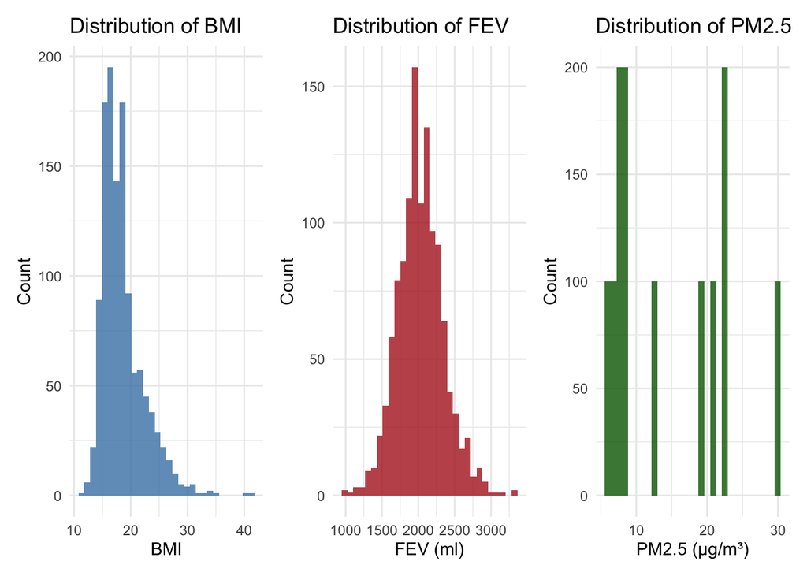

```r
#nothing looks out of place

# Distributions of continuous variables
p1 <- ggplot(chs_merged, aes(x = bmi)) +
  geom_histogram(bins = 30, fill = "steelblue", alpha = 0.8) +
  labs(title = "Distribution of BMI", x = "BMI", y = "Count") +
  theme_minimal()

p2 <- ggplot(chs_merged, aes(x = fev)) +
  geom_histogram(bins = 30, fill = "firebrick", alpha = 0.8) +
  labs(title = "Distribution of FEV", x = "FEV (ml)", y = "Count") +
  theme_minimal()

p3 <- ggplot(chs_merged, aes(x = pm25_mass)) +
  geom_histogram(bins = 30, fill = "darkgreen", alpha = 0.8) +
  labs(title = "Distribution of PM2.5", x = "PM2.5 (µg/m³)", y = "Count") +
  theme_minimal()

vars <- p1 | p2 | p3
vars
```

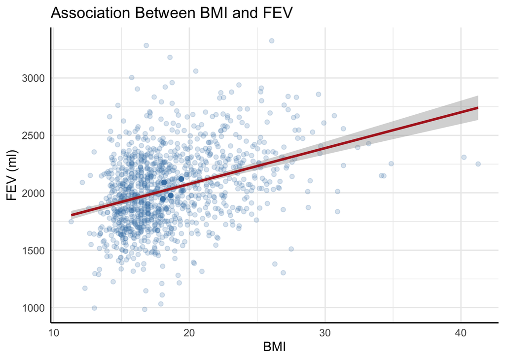

```r
# BMI vs. FEV

# Scatterplot with regression line
ggplot(chs_merged, aes(x = bmi, y = fev)) +
  geom_point(alpha = 0.2, color = "steelblue") +
  geom_smooth(method = "lm", color = "firebrick", se = TRUE) +
  labs(
    title = "Association Between BMI and FEV",
    x = "BMI",
    y = "FEV (ml)"
  ) +
  theme_minimal(base_size = 13) +
  theme(axis.line = element_line(color = "black"))
```

```r
# Correlation
cor(chs_merged$bmi, chs_merged$fev, use = "complete.obs")
```

```
[1] 0.357112
```

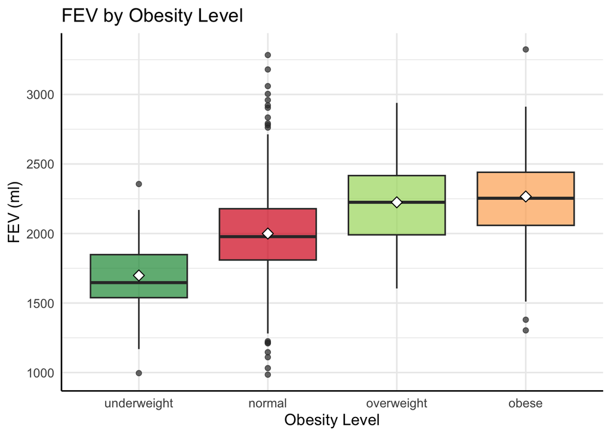

```r
# Boxplot by obesity category
ggplot(chs_merged, aes(x = obesity_level, y = fev, fill = obesity_level)) +
  geom_boxplot(alpha = 0.7) +
  stat_summary(fun = mean, geom = "point", shape = 23, size = 3,
               fill = "white", color = "black") +
  scale_fill_brewer(palette = "RdYlGn") +
  scale_x_discrete(limits = c("underweight", "normal", "overweight", "obese")) +
  labs(
    title = "FEV by Obesity Level",
    x = "Obesity Level",
    y = "FEV (ml)"
  ) +
  theme_minimal(base_size = 13) +
  theme(legend.position = "none",
        axis.line = element_line(color = "black"))
```

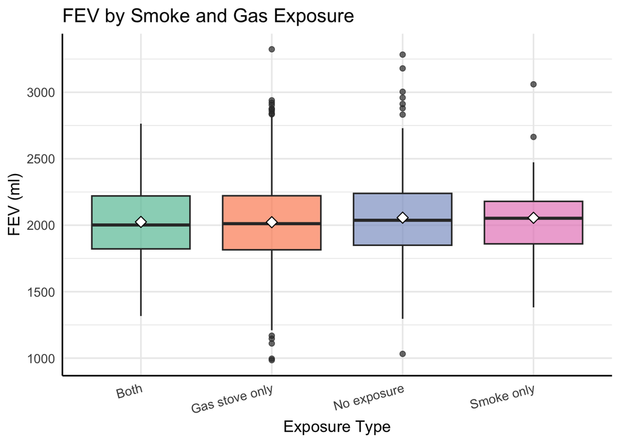

```r
# Smoke/gas exposure vs. FEV

ggplot(chs_merged, aes(x = smoke_gas_exposure, y = fev, fill = smoke_gas_exposure)) +
  geom_boxplot(alpha = 0.7) +
  stat_summary(fun = mean, geom = "point", shape = 23, size = 3,
               fill = "white", color = "black") +
  scale_fill_brewer(palette = "Set2") +
  labs(
    title = "FEV by Smoke and Gas Exposure",
    x = "Exposure Type",
    y = "FEV (ml)"
  ) +
  theme_minimal(base_size = 13) +
  theme(legend.position = "none",
        axis.line = element_line(color = "black"),
        axis.text.x = element_text(angle = 15, hjust = 1))
```

```r
# Summary table
chs_merged %>%
  dplyr::group_by(smoke_gas_exposure) %>%
  dplyr::summarise(
    mean_fev = round(mean(fev, na.rm = TRUE), 1),
    sd_fev   = round(sd(fev, na.rm = TRUE), 1),
    n        = n()
  )
```

```
# A tibble: 4 × 4
  smoke_gas_exposure mean_fev sd_fev     n
  <chr>                 <dbl>  <dbl> <int>
1 Both                  2025.   301.   154
2 Gas stove only        2023.   319.   791
3 No exposure           2057.   329.   219
4 Smoke only            2056.   296.    36
```

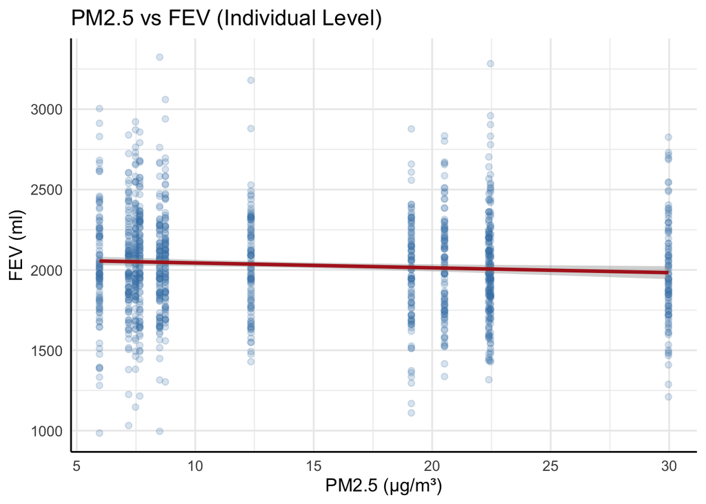

```r
# PM2.5 vs FEV

# Individual level
ggplot(chs_merged, aes(x = pm25_mass, y = fev)) +
  geom_point(alpha = 0.2, color = "steelblue") +
  geom_smooth(method = "lm", color = "firebrick", se = TRUE) +
  labs(
    title = "PM2.5 vs FEV (Individual Level)",
    x = "PM2.5 (µg/m³)",
    y = "FEV (ml)"
  ) +
  theme_minimal(base_size = 13) +
  theme(axis.line = element_line(color = "black"))
```

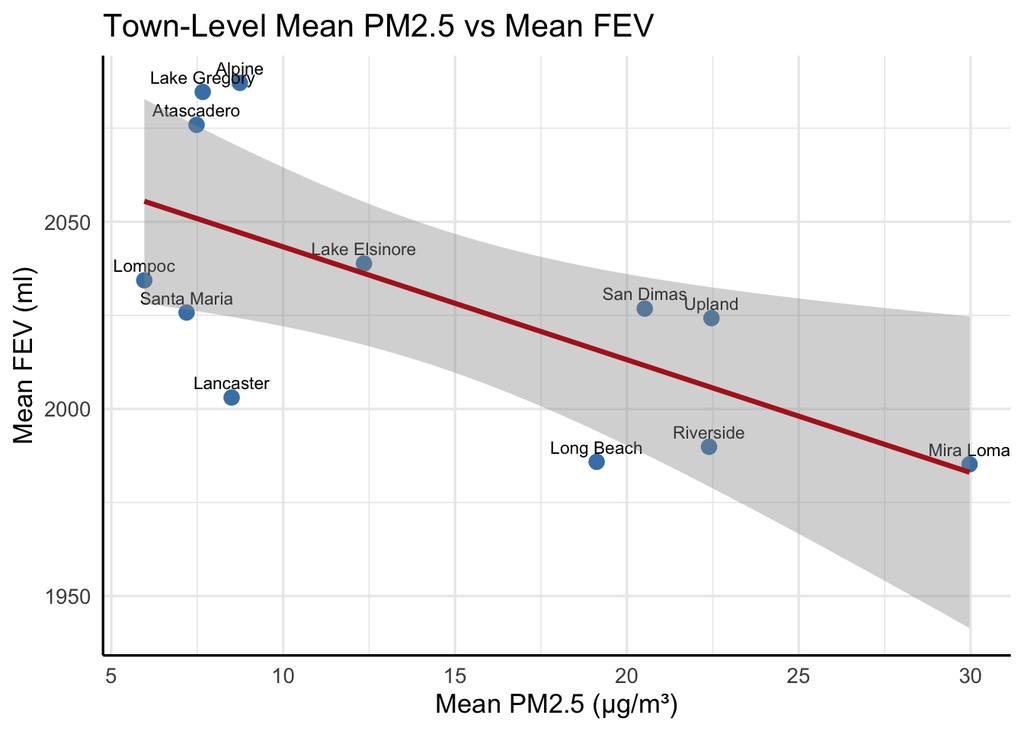

```r
# Town-level aggregation
chs_merged %>%
  dplyr::group_by(townname) %>%
  dplyr::summarise(
    mean_pm25 = mean(pm25_mass, na.rm = TRUE),
    mean_fev  = mean(fev, na.rm = TRUE)
  ) %>%
  ggplot(aes(x = mean_pm25, y = mean_fev, label = townname)) +
  geom_point(color = "steelblue", size = 3) +
  geom_text(vjust = -0.7, size = 3) +
  geom_smooth(method = "lm", color = "firebrick", se = TRUE) +
  labs(
    title = "Town-Level Mean PM2.5 vs Mean FEV",
    x = "Mean PM2.5 (µg/m³)",
    y = "Mean FEV (ml)"
  ) +
  theme_minimal(base_size = 13) +
  theme(axis.line = element_line(color = "black"))
```

```r
# Correlation at town level
chs_merged %>%
  dplyr::group_by(townname) %>%
  dplyr::summarise(
    mean_pm25 = mean(pm25_mass, na.rm = TRUE),
    mean_fev  = mean(fev, na.rm = TRUE)
  ) %>%
  summarise(cor = cor(mean_pm25, mean_fev))
```

```
# A tibble: 1 × 1
     cor
   <dbl>
1 -0.664
```

An increase in BMI appears to be associated with an increase in FEV. From the boxplot, it does not appear that FEV varies greatly across levels of smoke/gas exposure. Assessing the scatterplot of FEV vs PM2.5 at the town-level, it seems like a higher PM2.5 exposure is associated with lower FEV.

## Visualizations

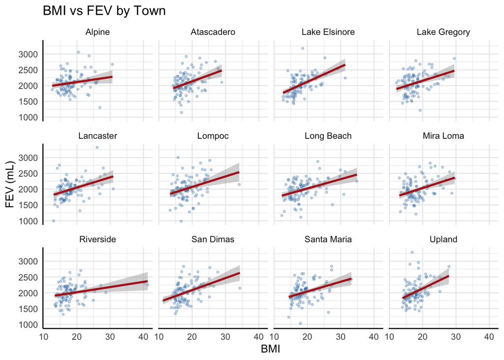

```r
library(ggplot2)
library(leaflet)

#Facet plot
ggplot(chs_merged, aes(x = bmi, y = fev)) +
  geom_point(alpha = 0.3, size = 0.8, color = "steelblue") +
  geom_smooth(method = "lm", color = "firebrick", se = TRUE) +
  facet_wrap(~ townname, ncol = 4) +
  labs(
    title = "BMI vs FEV by Town",
    x = "BMI",
    y = "FEV (mL)"
  ) +
  theme_minimal(base_size = 11) +
  theme(axis.line = element_line(color = "black"))
```

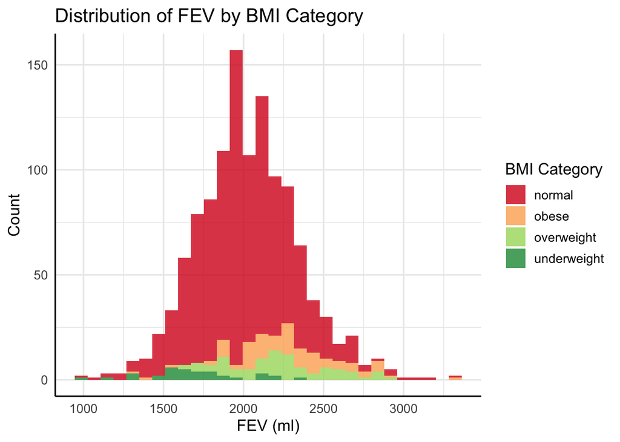

```r
#Stacked histogram: FEV by BMI category
ggplot(chs_merged, aes(x = fev, fill = obesity_level)) +
  geom_histogram(bins = 30, position = "stack", alpha = 0.8) +
  scale_fill_brewer(palette = "RdYlGn") +
  labs(
    title = "Distribution of FEV by BMI Category",
    x = "FEV (ml)",
    y = "Count",
    fill = "BMI Category"
  ) +
  theme_minimal(base_size = 13) +
  theme(axis.line = element_line(color = "black"))
```

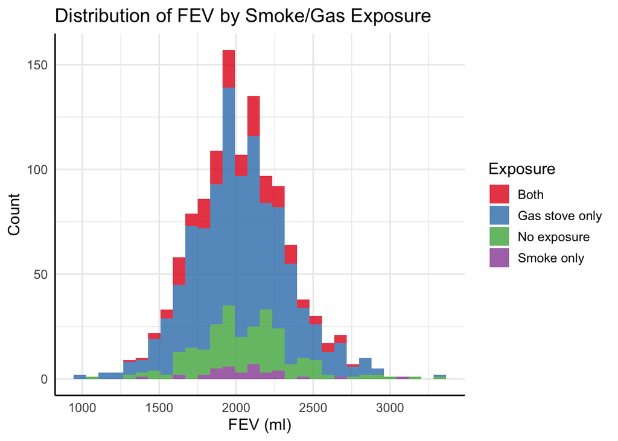

```r
#Stacked histogram: FEV by smoke/gas exposure
ggplot(chs_merged, aes(x = fev, fill = smoke_gas_exposure)) +
  geom_histogram(bins = 30, position = "stack", alpha = 0.8) +
  scale_fill_brewer(palette = "Set1") +
  labs(
    title = "Distribution of FEV by Smoke/Gas Exposure",
    x = "FEV (ml)",
    y = "Count",
    fill = "Exposure"
  ) +
  theme_minimal(base_size = 13) +
  theme(axis.line = element_line(color = "black"))
```

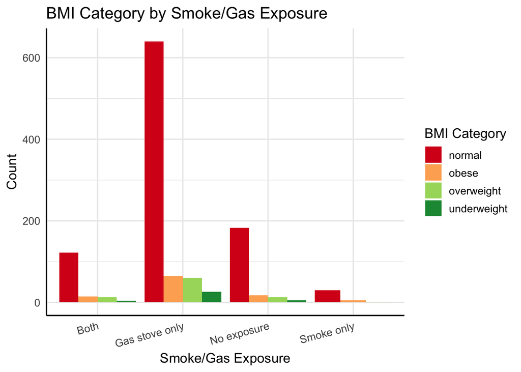

```r
#Bar chart of BMI by smoke/gas exposure
ggplot(chs_merged, aes(x = smoke_gas_exposure, fill = obesity_level)) +
  geom_bar(position = "dodge") +
  scale_fill_brewer(palette = "RdYlGn") +
  labs(
    title = "BMI Category by Smoke/Gas Exposure",
    x = "Smoke/Gas Exposure",
    y = "Count",
    fill = "BMI Category"
  ) +
  theme_minimal(base_size = 13) +
  theme(
    axis.line = element_line(color = "black"),
    axis.text.x = element_text(angle = 15, hjust = 1)
  )
```

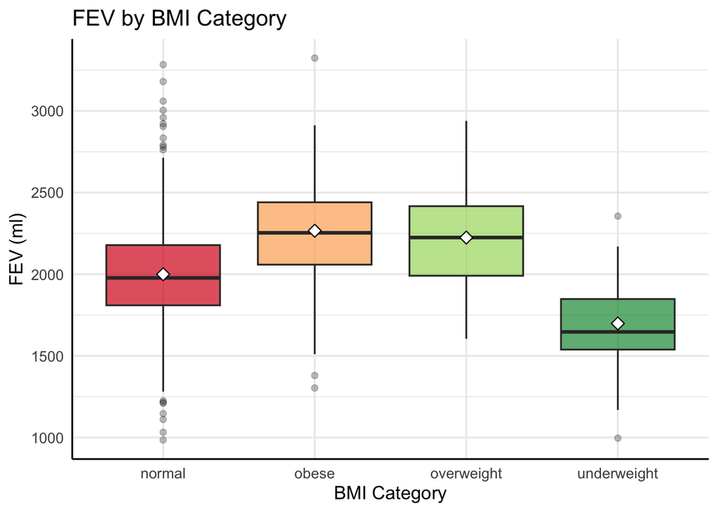

```r
#Statistical summary graphs of FEV by BMI and FEV by smoke/gas exposure category
ggplot(chs_merged, aes(x = obesity_level, y = fev, fill = obesity_level)) +
  geom_boxplot(alpha = 0.7, outlier.alpha = 0.3) +
  stat_summary(fun = mean, geom = "point", shape = 23, size = 3,
               fill = "white", color = "black") +
  scale_fill_brewer(palette = "RdYlGn") +
  labs(
    title = "FEV by BMI Category",
    x = "BMI Category",
    y = "FEV (ml)",
    fill = ""
  ) +
  theme_minimal(base_size = 13) +
  theme(legend.position = "none",
        axis.line = element_line(color = "black"))
```

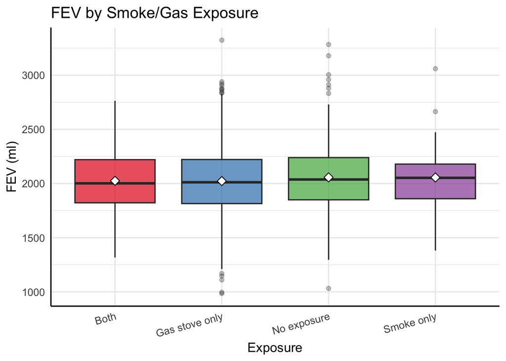

```r
ggplot(chs_merged, aes(x = smoke_gas_exposure, y = fev, fill = smoke_gas_exposure)) +
  geom_boxplot(alpha = 0.7, outlier.alpha = 0.3) +
  stat_summary(fun = mean, geom = "point", shape = 23, size = 3,
               fill = "white", color = "black") +
  scale_fill_brewer(palette = "Set1") +
  labs(
    title = "FEV by Smoke/Gas Exposure",
    x = "Exposure",
    y = "FEV (ml)",
    fill = ""
  ) +
  theme_minimal(base_size = 13) +
  theme(legend.position = "none",
        axis.line = element_line(color = "black"),
        axis.text.x = element_text(angle = 15, hjust = 1))
```

```r
#A leaflet map showing the concentrations of PM2.5 mass in each of the CHS communities
pm25_towns <- chs_merged %>%
  dplyr::group_by(townname) %>%
  dplyr::summarise(
    pm25  = mean(pm25_mass, na.rm = TRUE),
    lat   = mean(lat, na.rm = TRUE),
    lon   = mean(lon, na.rm = TRUE)
  )

pal <- colorNumeric(palette = "YlOrRd", domain = pm25_towns$pm25)

leaflet(pm25_towns) %>%
  addTiles() %>%
  addCircleMarkers(
    lng    = ~lon,
    lat    = ~lat,
    radius = ~pm25 / 2,
    color  = ~pal(pm25),
    fillOpacity = 0.8,
    label  = ~paste0(townname, ": ", round(pm25, 1), " µg/m³")
  ) %>%
  addLegend(
    position = "bottomright",
    pal      = pal,
    values   = ~pm25,
    title    = "PM2.5 (µg/m³)"
  )
```

[interactive chart not shown]

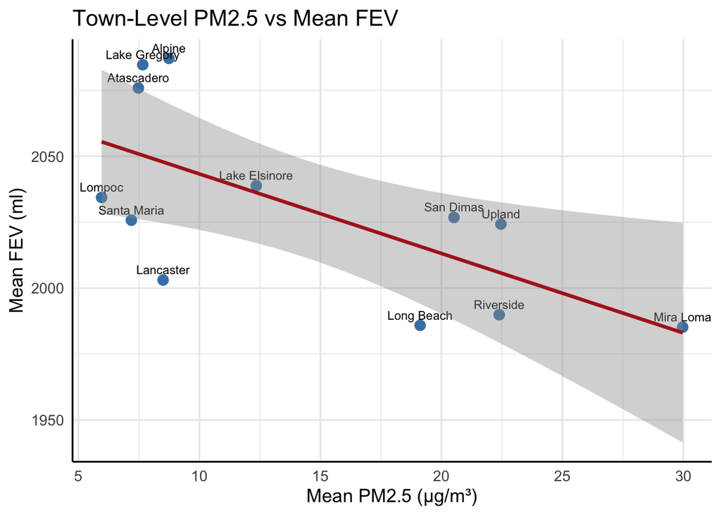

```r
# Is PM2.5 associated with FEV?
chs_merged %>%
  dplyr::group_by(townname) %>%
  dplyr::summarise(
    mean_pm25 = mean(pm25_mass, na.rm = TRUE),
    mean_fev  = mean(fev, na.rm = TRUE)
  ) %>%
  ggplot(aes(x = mean_pm25, y = mean_fev, label = townname)) +
  geom_point(color = "steelblue", size = 3) +
  geom_text(vjust = -0.7, size = 3) +
  geom_smooth(method = "lm", color = "firebrick", se = TRUE) +
  labs(
    title = "Town-Level PM2.5 vs Mean FEV",
    x     = "Mean PM2.5 (µg/m³)",
    y     = "Mean FEV (ml)"
  ) +
  theme_minimal(base_size = 13) +
  theme(axis.line = element_line(color = "black"))
```

From our final visualization, it appears that a higher PM2.5 value is associated with a lower FEV, indicating that PM2.5 exposure is a risk factor for poor lung function.